CMSC 320 - Final Project: A Tutorial - Alex Arner

# Spotify Song Analysis

A question the music industry has been pondering for decades is how possible it is to predict a songs popularity. Popularity means increased sales figures after all, so this question is of great significane. We intrinsically know that a popular song has to be catchy, memorable, and has a good beat. But how can we quantify this? Can we prove or derive a formula to predict popularity based on several various attributes?

In this tutorial, I'd like to examine if there are any similarities between popular songs. What overlaps are there? Happy, uplifting songs? Some other combination of variables?

Good thing theres an API to examine exactly this.

The Spotify API allows song data to be accessed and analyzed. There are 13 variables we will consider in this tutorial:

- popularity
  - "The popularity of a track is a value between 0 and 100, with 100 being the most popular. The popularity is calculated by algorithm and is based, in the most part, on the total number of plays the track has had and how recent those plays are."
- duration_ms
  - length of song, in milliseconds
- danceability
  - "Danceability describes how suitable a track is for dancing based on a combination of musical elements including tempo, rhythm stability, beat strength, and overall regularity. A value of 0.0 is least danceable and 1.0 is most danceable."
- energy
  - "Energy is a measure from 0.0 to 1.0 and represents a perceptual measure of intensity and activity. Typically, energetic tracks feel fast, loud, and noisy. For example, death metal has high energy, while a Bach prelude scores low on the scale. Perceptual features contributing to this attribute include dynamic range, perceived loudness, timbre, onset rate, and general entropy."
- key
  - "The key the track is in. Integers map to pitches using standard Pitch Class notation. E.g. 0 = C, 1 = C♯/D♭, 2 = D, and so on. If no key was detected, the value is -1."
- loudness
  - in decibels (dB). typically range between -60 and 0 db.
- mode
  - modality (major or minor) of a track, the type of scale from which its melodic content is derived. Major is represented by 1 and minor is 0."
- speechiness
  - "The more exclusively speech-like the recording (e.g. talk show, audio book, poetry), the closer to 1.0 the attribute value. Values above 0.66 describe tracks that are probably made entirely of spoken words. Values between 0.33 and 0.66 describe tracks that may contain both music and speech, either in sections or layered, including such cases as rap music. Values below 0.33 most likely represent music and other non-speech-like tracks."
- acousticness
  - "A confidence measure from 0.0 to 1.0 of whether the track is acoustic. 1.0 represents high confidence the track is acoustic."
- instrumentalness
  - "Predicts whether a track contains no vocals. "Ooh" and "aah" sounds are treated as instrumental in this context. Rap or spoken word tracks are clearly "vocal". The closer the instrumentalness value is to 1.0, the greater likelihood the track contains no vocal content. Values above 0.5 are intended to represent instrumental tracks, but confidence is higher as the value approaches 1.0."
- liveness
  - "Detects the presence of an audience in the recording. Higher liveness values represent an increased probability that the track was performed live. A value above 0.8 provides strong likelihood that the track is live."
- valence
  - "A measure from 0.0 to 1.0 describing the musical positiveness conveyed by a track. Tracks with high valence sound more positive (e.g. happy, cheerful, euphoric), while tracks with low valence sound more negative (e.g. sad, depressed, angry)."
- tempo
  - "The overall estimated tempo of a track in beats per minute (BPM). In musical terminology, tempo is the speed or pace of a given piece and derives directly from the average beat duration."

A full reference to these variables can be found here (https://developer.spotify.com/documentation/web-api/reference/#/operations/get-several-audio-features).

Given a combination of these variables, could any given song be predicted to be popular or not? If so, could songs be created with these variables in mind?

```python
import pandas as pd
import matplotlib.pyplot as plt
import numpy as np

import spotipy
from spotipy.oauth2 import SpotifyClientCredentials

cid = '24260dfcebf9416e8b058630b2c9fc37'
secret = '0f1b9180921e4167ad82f7149c36cd85'

client_credentials_manager = SpotifyClientCredentials(client_id=cid, client_secret=secret)
sp = spotipy.Spotify(client_credentials_manager = client_credentials_manager)
```

# Data Collection, Cleaning, and Management

In this section we will download song data from select Spotify playlists and use it to construct a .csv file.

The selected playlists are the following: (ideally first 100 songs of each)

- "Greatest 90s Music Hits - Best Songs of 1990 to 2000" by redmusiccompany
  - https://open.spotify.com/playlist/0y0ZEQHqEdMPnQKqRKhSmn
- "2000s-2010s bangers" by gians85
  - https://open.spotify.com/playlist/15sZyUgStYmvzm3QfdVDIp
- "BEST SONGS 2010-2021" by BEST SONGS
  - https://open.spotify.com/playlist/1PIhV6X7PV4TjAQb7unitN

These playlists were selected arbitrarily. I desired to get some sample of songs spanning a decent period of time; the inclusion of 1990s to 2021 songs fulfils this concern. Ideally I'd want to limit bias from my datasets whenever possible. If not possible, then keeping this in mind is paramount in analysing data properly.

Since data is being pulled from 3 separate sources, ensure there are no duplicates in the final dataframe. The analysis that follows will work with the first 100 songs of these 3 playlists.

We save this data into a csv for sake of backup. Just in case Spotify API crashes or some connection issue occurs, this csv ensures our data is never gone forever.

```python
# This is the column array for the final result of this section, a clean dataframe backed up by a csv export
track_columns = ['id', 'name', 'artist', 'popularity', 'duration_ms', 'danceability', 'energy', 'key', 'loudness', 'mode', 'speechiness', 'acousticness', 'instrumentalness', 'liveness', 'valence', 'tempo']


# this function adds the 'playlist_link' playlist's songs into the 'playlist_df' dataframe
#   ensures no repeat songs (checks by ID)
#   playlist_link: string of spotify url

def obtain_clean_playlist(playlist_df, playlist_link):

    playlist_URI = playlist_link.split("/")[-1].split("?")[0]
    playlist = sp.playlist(playlist_URI)

    print('Playlist Name: ' + str(playlist['name']))
    print('Playlist Author: ' + str(playlist['owner']['display_name']))
    print()

    added = 0
    for track in playlist['tracks']['items']:
        aud = sp.audio_features(track['track']['id'])

        id = track['track']['id']

        if len(playlist_df[playlist_df.id == id]) == 0:

            to_add = list()

            to_add.append(id)
            to_add.append(track['track']['name'])
            to_add.append(track['track']['artists'][0]['name'])
            to_add.append(track['track']['popularity'])
            to_add.append(track['track']['duration_ms'])
            to_add.append(aud[0]['danceability'])
            to_add.append(aud[0]['energy'])
            to_add.append(aud[0]['key'])
            to_add.append(aud[0]['loudness'])
            to_add.append(aud[0]['mode'])
            to_add.append(aud[0]['speechiness'])
            to_add.append(aud[0]['acousticness'])
            to_add.append(aud[0]['instrumentalness'])
            to_add.append(aud[0]['liveness'])
            to_add.append(aud[0]['valence'])
            to_add.append(aud[0]['tempo'])

            playlist_df.loc[len(playlist_df.index)] = to_add
            added += 1

    print('\ttotal tracks added to dataframe: ' + str(added))
    print()

    return playlist_df


playlist_df = pd.DataFrame(columns = track_columns)

playlist_1990s = "https://open.spotify.com/playlist/0y0ZEQHqEdMPnQKqRKhSmn"
playlist_2000s = "https://open.spotify.com/playlist/15sZyUgStYmvzm3QfdVDIp"
playlist_2010s = "https://open.spotify.com/playlist/1PIhV6X7PV4TjAQb7unitN"

playlist_df = obtain_clean_playlist(playlist_df, playlist_1990s)
playlist_df = obtain_clean_playlist(playlist_df, playlist_2000s)
playlist_df = obtain_clean_playlist(playlist_df, playlist_2010s)

playlist_df.to_csv('track_data.csv')

print('finished')

# due to the quantity of songs processed, this section is slow to process (at least on my computer)
```

```
Playlist Name: Greatest 90s Music Hits - Best Songs of 1990 to 2000
Playlist Author: redmusiccompany

	total tracks added to dataframe: 100

Playlist Name: 2000s-2010s bangers
Playlist Author: gians85

	total tracks added to dataframe: 99

Playlist Name: BEST SONGS 2010-2021
Playlist Author: BEST SONGS

	total tracks added to dataframe: 97

finished
```

# Data Visualization/Representation

Lets try to get a picture of this dataset. We know that these songs were pulled from 'best songs' and 'bangers' playlists, so there might be some bias towards uplifting, faster songs (energy, tempo, loudness, valence).

Best thing to start out with is to see the aggregate statistics of the different columns.

```python
print('size: ' + str(len(playlist_df)))
# note: track_columns[3] -> 'popularity'
i = 3
while i < len(track_columns):
    print(str(track_columns[i]))
    print('\t mean:    '+ str(playlist_df[track_columns[i]].mean()))
    print('\t std:     '+ str(playlist_df[track_columns[i]].std()))
    print('\t median:  '+ str(playlist_df[track_columns[i]].median()))
    print('\t max:     '+ str(playlist_df[track_columns[i]].max()))
    print('\t min:     '+ str(playlist_df[track_columns[i]].min()))
    print()
    i += 1
```

```
size: 296
popularity
	 mean:    54.763513513513516
	 std:     28.94901690002241
	 median:  68.0
	 max:     100
	 min:     0

duration_ms
	 mean:    236115.5777027027
	 std:     58818.80957907109
	 median:  227556.5
	 max:     721000
	 min:     124009

danceability
	 mean:    0.6526554054054051
	 std:     0.13919517880009716
	 median:  0.664
	 max:     0.967
	 min:     0.252

energy
	 mean:    0.7092635135135136
	 std:     0.16506082541885087
	 median:  0.7304999999999999
	 max:     0.974
	 min:     0.127

key
	 mean:    5.027027027027027
	 std:     3.5671684558606707
	 median:  5.0
	 max:     11
	 min:     0

loudness
	 mean:    -6.231165540540539
	 std:     2.3703872607073673
	 median:  -5.822
```

[output cut: 36 more lines]

```
	 min:     0.0248

valence
	 mean:    0.5580878378378377
	 std:     0.23020901126699952
	 median:  0.569
	 max:     0.969
	 min:     0.1

tempo
	 mean:    119.52399324324327
	 std:     26.206815538024106
	 median:  120.007
	 max:     205.846
	 min:     67.007
```

Now lets look at 2d variable to variable graphs. We can possibly notice correlation and/or clustering with some variable combinations on these graphs. It is often very helpful and faster to visually notice a trend rather than relying on mathematical models alone.

```
# we can limit the # of graphs displayed to 5. Can be changed, but causes page to become too long.
total_graphs = 12

graph_size = (10, 8)


i = 3
while i < len(track_columns):

    j = 3
    while j < len(track_columns):
        if (not track_columns[j] == track_columns[i]) and i > j:
            # playlist_df.plot(kind = 'scatter', x = track_columns[j], y = track_columns[i], figsize = graph_size)
            total_graphs -= 1
            if total_graphs == 0:
                i = len(track_columns)
                j = i
        j += 1

    i += 1


# With 13 variables, to have each graph being a unique pairing, ((13*13) - 13) / 2 = 78 different graphs in total are needed.
```

However, I have looked through these graphs and noticed some interesting trends. I will show a select few below.

# Exploratory data analysis

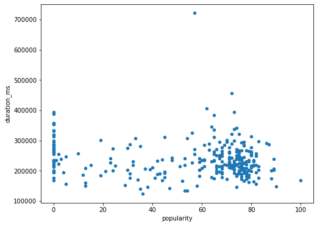

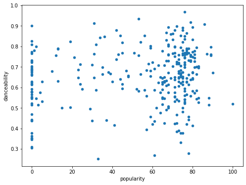

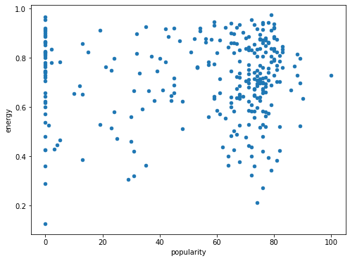

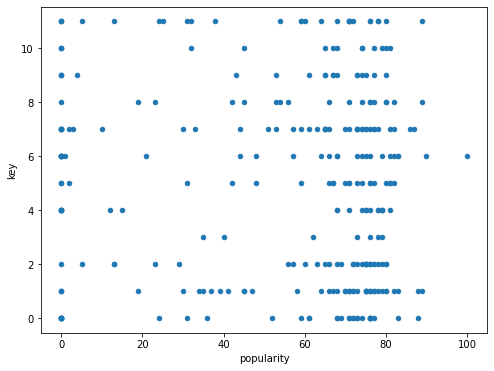

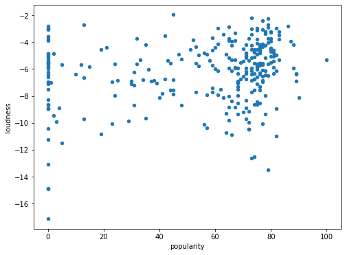

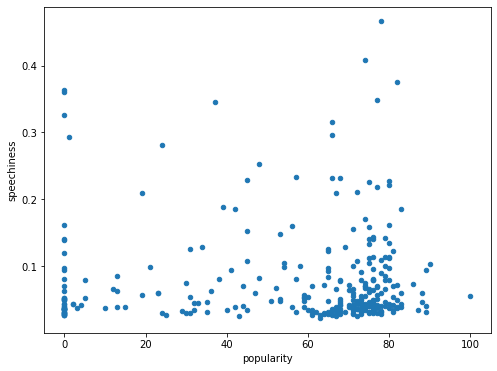

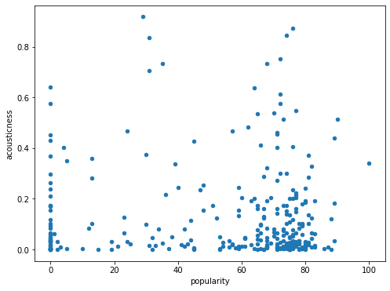

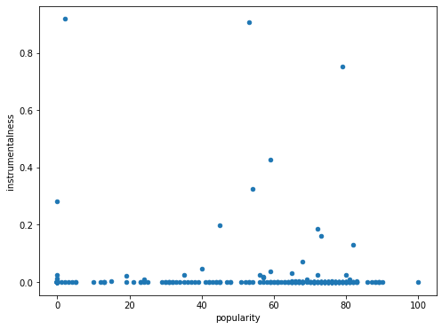

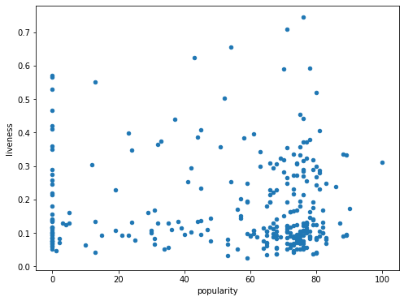

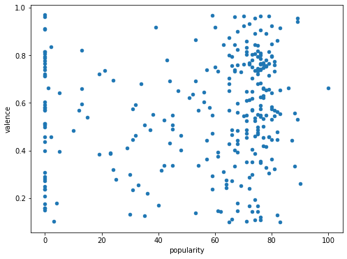

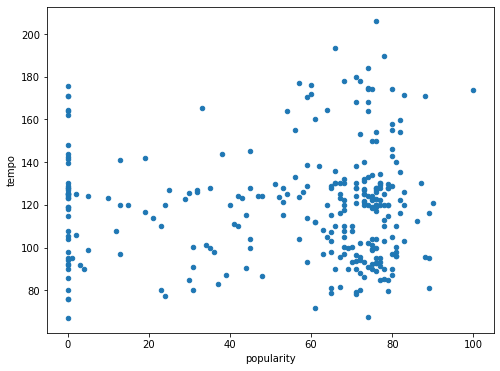

```python
# Lets now examine popularity and see if we can notice any trends.

x_var = 'popularity'

graph_size = (8, 6)


i = 3
while i < len(track_columns):

    if not x_var == track_columns[i] and not track_columns[i] == 'mode':
        playlist_df.plot(kind = 'scatter', x = x_var, y = track_columns[i], figsize = graph_size)
    i += 1


plt.show()
```

There appears to be a two signifcant clusters in this dataset: popularity close to 0 and popularity between 60 and 80. Visually, it seems that the dataset trends towards moderate tempo/valence, little lower in liveness, low in acousticness and speechiness, very low in instrumentalness, and higher in loudness and energy. Its very interesting that several all hold roughly similar patterns. The scatters are of course different in signficant ways but nonetheless theres patterns between variables. This will be discussed further later in this tutorial. Additionally, it seems that this dataset is skewed towards songs below 5 minutes (majority clustered below 300000 for duration_ms). I would suspect that this skew was due to the music industry and their production standards. There is a precedent in the music industry that songs must be of certain length. Historic reasons most likely caused this trend. Now lets look at the distribution of popularity values.

```
array([[<AxesSubplot:title={'center':'popularity'}>]], dtype=object)
```

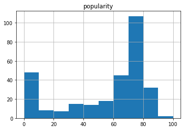

```python
playlist_df.hist(column='popularity')
```

This chart illustrates the magnitude of these two clusters of data.

According to this histogram, theres a large population from popularity levels 60 to 90, and a smaller but still significant cluster at lower values.

These lower popularity levels are suprising; didn't these playlists indicate in their titles that they're hit songs?

```python
df_unliked = playlist_df[playlist_df.popularity <= 10]
df_unliked.head()
```

|  | id | name | artist | popularity | duration_ms | danceability | energy | key | loudness | mode | speechiness | acousticness | instrumentalness | liveness | valence | tempo |
| --- | --- | --- | --- | --- | --- | --- | --- | --- | --- | --- | --- | --- | --- | --- | --- | --- |
| 7 | 6b2oQwSGFkzsMtQruIWm2p | Creep | Radiohead | 3 | 238640 | 0.515 | 0.430 | 7 | -9.935 | 1 | 0.0369 | 0.0102 | 0.000141 | 0.129 | 0.104 | 91.841 |
| 9 | 7atIHMnLUJ5ikdnosz1GwU | Barbie Girl | Aqua | 0 | 197906 | 0.810 | 0.956 | 1 | -5.753 | 0 | 0.0367 | 0.0167 | 0.281000 | 0.350 | 0.961 | 129.996 |
| 10 | 1MAqR81Tz28IIqMJ2KUDAO | Killing Me Softly With His Song | Fugees | 0 | 298773 | 0.765 | 0.290 | 4 | -17.117 | 0 | 0.1390 | 0.0279 | 0.000001 | 0.571 | 0.506 | 92.409 |
| 12 | 1znPMY3zq78mVuTAmOA9O7 | Nothing Else Matters | Metallica | 0 | 388266 | 0.553 | 0.362 | 4 | -11.218 | 0 | 0.0263 | 0.0458 | 0.000006 | 0.075 | 0.158 | 142.352 |
| 13 | 2wVXSc0IrQVodHESUxVUJA | Losing My Religion | R.E.M. | 0 | 268426 | 0.664 | 0.852 | 9 | -4.996 | 0 | 0.0290 | 0.1740 | 0.000000 | 0.100 | 0.807 | 125.632 |

Perhaps this skew is due to the old age of the 90s playlist. Popularity rating does factor in recent plays.

The previous popularity graphs show that the majority of the most popular songs (within the 60-90 cluster) have low liveness, acousticness, and speechiness ratings. I would hypothesize that this is at or below the mean of these metrics.

speechiness

- mean: 0.07937432432432434
- std: 0.07353220451772696
- median: 0.0501
- max: 0.466
- min: 0.0225

acousticness

- mean: 0.13028789459459467
- std: 0.18219553384572634
- median: 0.04725
- max: 0.919
- min: 2.55e-05

liveness

- mean: 0.17684189189189176
- std: 0.13401707531657525
- median: 0.1215
- max: 0.744
- min: 0.0248

This next section will be several graphs to highlight some additional trends.

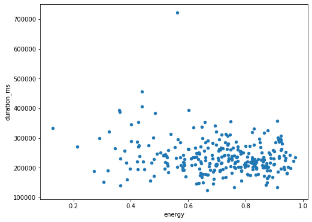

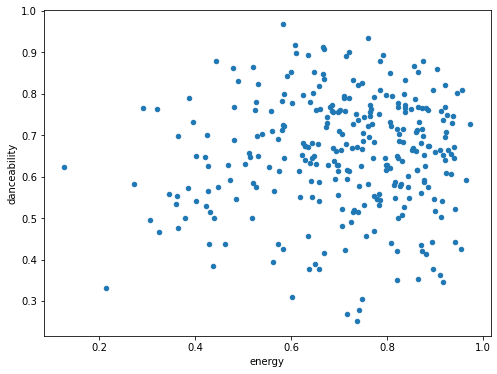

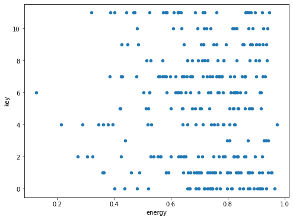

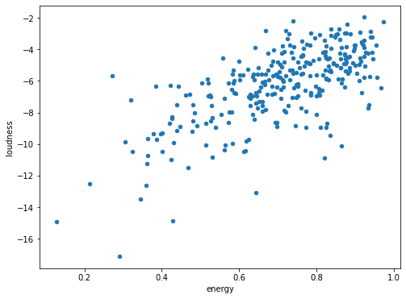

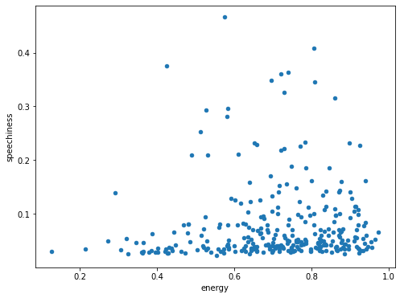

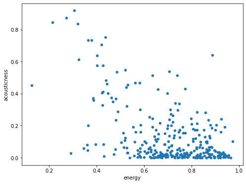

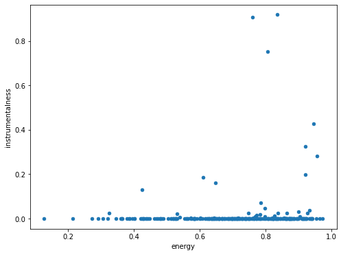

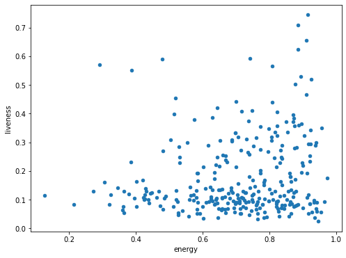

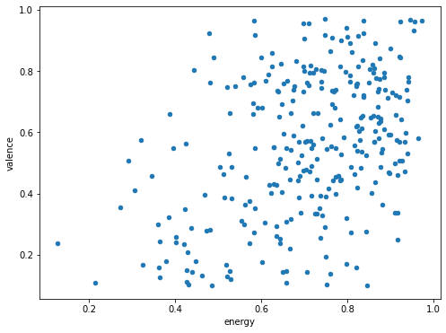

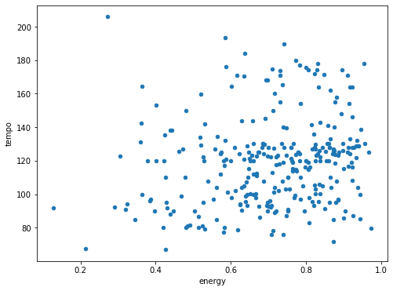

```python
x_var = 'energy'

graph_size = (8, 6)


i = 3
while i < len(track_columns):

    if not x_var == track_columns[i] and not track_columns[i] == 'mode' and not track_columns[i] == 'popularity':
        playlist_df.plot(kind = 'scatter', x = x_var, y = track_columns[i], figsize = graph_size)
    i += 1


plt.show()
```

Some Brief Key Insights:

- There appears to be a positive correlation with energy v loudness
- energy v acousticness seems to have a negative correlation
- there seems to be a skew towards higher energy

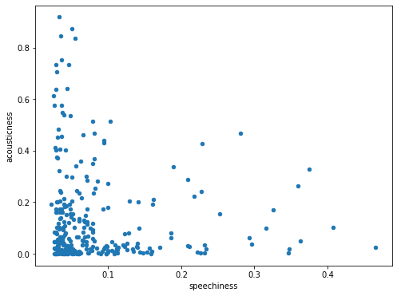

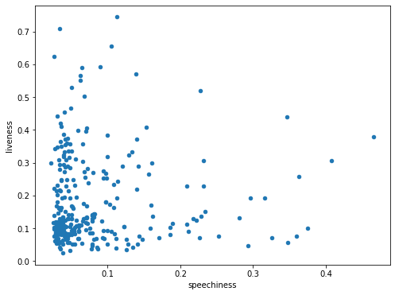

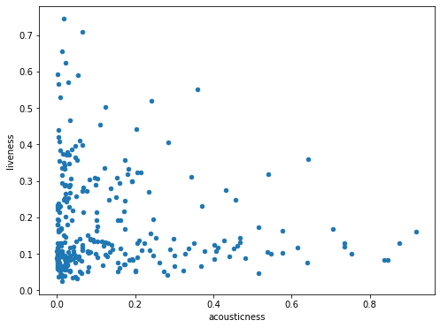

```python
playlist_df.plot(kind = 'scatter', x = 'speechiness', y = 'acousticness', figsize = graph_size)
playlist_df.plot(kind = 'scatter', x = 'speechiness', y = 'liveness', figsize = graph_size)
playlist_df.plot(kind = 'scatter', x = 'acousticness', y = 'liveness', figsize = graph_size)
```

These are very unique graphs compared to the others. These graphs have significant clustering close to the origin sprawling out. Might there be a concentration of low acousticness, speechiness, and/or liveness songs in this dataset?

In summary, several hypotheses can be theorized from these graphs:

- are acousticness, speechiness, and liveness are related?
- are energy v loudness are positively correlated?
- are energy v acousticness are negatively correlated?
- do songs with popularity rating between 60 and 90 have liveness, acousticness, and speechiness rating at or below the mean?

In the next several sections, we shall test these hypotheses and see if they can be validated.

# Hypothesis Testing

```python
playlist_df.corr()
```

|  | popularity | duration_ms | danceability | energy | key | loudness | mode | speechiness | acousticness | instrumentalness | liveness | valence | tempo |
| --- | --- | --- | --- | --- | --- | --- | --- | --- | --- | --- | --- | --- | --- |
| popularity | 1.000000 | -0.135695 | 0.166618 | 0.061449 | -0.049112 | 0.209813 | 0.074440 | 0.006396 | -0.030370 | -0.048985 | -0.024560 | 0.120442 | 0.052794 |
| duration_ms | -0.135695 | 1.000000 | -0.318171 | -0.177655 | -0.044943 | -0.247730 | 0.087513 | -0.104406 | 0.123911 | -0.033284 | -0.070431 | -0.228740 | 0.020698 |
| danceability | 0.166618 | -0.318171 | 1.000000 | 0.056977 | 0.099331 | 0.082744 | -0.117073 | 0.148052 | -0.078297 | 0.180658 | -0.077325 | 0.479922 | -0.238851 |
| energy | 0.061449 | -0.177655 | 0.056977 | 1.000000 | -0.052949 | 0.679775 | -0.143800 | 0.046513 | -0.544197 | 0.104414 | 0.152320 | 0.421362 | 0.180015 |
| key | -0.049112 | -0.044943 | 0.099331 | -0.052949 | 1.000000 | -0.031674 | -0.024911 | 0.120605 | -0.006263 | 0.045496 | -0.007901 | 0.022143 | -0.044947 |
| loudness | 0.209813 | -0.247730 | 0.082744 | 0.679775 | -0.031674 | 1.000000 | -0.099331 | 0.037296 | -0.300585 | -0.041685 | 0.044034 | 0.287911 | 0.186471 |
| mode | 0.074440 | 0.087513 | -0.117073 | -0.143800 | -0.024911 | -0.099331 | 1.000000 | -0.049034 | 0.113659 | -0.086359 | -0.079507 | -0.150959 | -0.057190 |
| speechiness | 0.006396 | -0.104406 | 0.148052 | 0.046513 | 0.120605 | 0.037296 | -0.049034 | 1.000000 | -0.066746 | 0.038628 | 0.060052 | 0.155359 | -0.001808 |
| acousticness | -0.030370 | 0.123911 | -0.078297 | -0.544197 | -0.006263 | -0.300585 | 0.113659 | -0.066746 | 1.000000 | -0.071863 | -0.081726 | -0.231028 | -0.156199 |
| instrumentalness | -0.048985 | -0.033284 | 0.180658 | 0.104414 | 0.045496 | -0.041685 | -0.086359 | 0.038628 | -0.071863 | 1.000000 | -0.036998 | 0.156049 | 0.017167 |
| liveness | -0.024560 | -0.070431 | -0.077325 | 0.152320 | -0.007901 | 0.044034 | -0.079507 | 0.060052 | -0.081726 | -0.036998 | 1.000000 | 0.024695 | 0.036598 |
| valence | 0.120442 | -0.228740 | 0.479922 | 0.421362 | 0.022143 | 0.287911 | -0.150959 | 0.155359 | -0.231028 | 0.156049 | 0.024695 | 1.000000 | -0.021589 |
| tempo | 0.052794 | 0.020698 | -0.238851 | 0.180015 | -0.044947 | 0.186471 | -0.057190 | -0.001808 | -0.156199 | 0.017167 | 0.036598 | -0.021589 | 1.000000 |

Significant Highlights:

- energy & loudness are correlated at 0.679775
- energy & acousticness are correlated at -0.544197
- popularity & loudness are correlated at 0.209813

```python
playlist_df.corr()['popularity'].map(abs, na_action='ignore').sort_values(ascending = False)
```

```
popularity          1.000000
loudness            0.209813
danceability        0.166618
duration_ms         0.135695
valence             0.120442
mode                0.074440
energy              0.061449
tempo               0.052794
key                 0.049112
instrumentalness    0.048985
acousticness        0.030370
liveness            0.024560
speechiness         0.006396
Name: popularity, dtype: float64
```

```python
# this is a list of correlations after transforming them to their absolute value.
#   lets compare populartity's list above with energy's correlations below.

playlist_df.corr()['energy'].map(abs, na_action='ignore').sort_values(ascending = False)
```

```
energy              1.000000
loudness            0.679775
acousticness        0.544197
valence             0.421362
tempo               0.180015
duration_ms         0.177655
liveness            0.152320
mode                0.143800
instrumentalness    0.104414
popularity          0.061449
danceability        0.056977
key                 0.052949
speechiness         0.046513
Name: energy, dtype: float64
```

Now lets try to apply multivariate linear regression to predict energy. From the correlations in the above output, it seems that energy is greatly correlated with loutness, acousticness, and valence.

Lets see the results of multiple regressions and how accurate of a model we can obtain.

```python
from sklearn.linear_model import LinearRegression

# loudness v energy

model = LinearRegression()

X = playlist_df[['loudness']]
y = playlist_df['energy']

model.fit(X, y)

print('intercept:', model.intercept_)
print('slope:', model.coef_)

print('coefficient of determination:', model.score(X, y))
```

```
intercept: 1.0042206626798011
slope: 0.04733579091219277
coefficient of determination: 0.46209350004286653
```

```python
# acousticness v energy

model = LinearRegression()

X = playlist_df[['acousticness']]
y = playlist_df['energy']

model.fit(X, y)

print('intercept:', model.intercept_)
print('slope:', model.coef_)

print('coefficient of determination:', model.score(X, y))
```

```
intercept: 0.7734977954380542
slope: -0.4930180361300087
coefficient of determination: 0.29615089096504377
```

```python
# (acousticness & loudness) v energy

model = LinearRegression()

X = playlist_df[['acousticness', 'loudness']]
y = playlist_df['energy']

model.fit(X, y)

print('intercept:', model.intercept_)
print('slope:', model.coef_)

print('coefficient of determination:', model.score(X, y))
```

[output not shown]

```python
# valence v energy

model = LinearRegression()

X = playlist_df[['valence']]
y = playlist_df['energy']

model.fit(X, y)

print('intercept:', model.intercept_)
print('slope:', model.coef_)

print('coefficient of determination:', model.score(X, y))
```

```
intercept: 0.5406548149501201
slope: 0.3021185683182468
coefficient of determination: 0.17754622798858588
```

```python
# (acousticness, loudness, & valence) v energy

model = LinearRegression()

X = playlist_df[['acousticness', 'loudness', 'valence']]
y = playlist_df['energy']

model.fit(X, y)

print('intercept:', model.intercept_)
print('slope:', model.coef_)

print('coefficient of determination:', model.score(X, y))
```

```
intercept: 0.8991627810734654
slope: [-0.31086083  0.03630469  0.13765333]
coefficient of determination: 0.6220332578064509
```

From the above operations, we showed that single variable input regression doesn't produce as good of a model as multivarate regression with 3 significantly correlating variables. The last model created can somewhat confidently (very rough precision) predict the energy rating.

```python
# for a quick example, lets select dataframe row index 23 randomly

print(str(playlist_df.loc[23]['energy']))
model.predict([[playlist_df.loc[23]['acousticness'], playlist_df.loc[23]['loudness'], playlist_df.loc[23]['valence']]])[0]
```

```
0.699
```

```
/opt/conda/lib/python3.9/site-packages/sklearn/base.py:450: UserWarning: X does not have valid feature names, but LinearRegression was fitted with feature names
  warnings.warn(
```

```
0.7526500377315801
```

Ignore the warning.

The result of 0.75265 is pretty close to 0.699. If we added tempo (the next highest correlating variable), could we improve the model further? What if tempo is added as an additional input variable?

```python
# (acousticness, loudness, valence, & tempo) v energy

model = LinearRegression()

X = playlist_df[['acousticness', 'loudness', 'valence', 'tempo']]
y = playlist_df['energy']

model.fit(X, y)

print('intercept:', model.intercept_)
print('slope:', model.coef_[0])

print('coefficient of determination:', model.score(X, y))
```

```
intercept: 0.8679071901704417
slope: -0.3068231691990631
coefficient of determination: 0.6232099671268112
```

Very Interesting. There is only a marginal increase of the coefficient of determination when tempo is included in the regression input. I would suspect that as more variables are added the coefficient of determination will hit a value ceiling.

Unfortunately for us, popularity isn't as simple as this energy rating. The popularity correlations are printed below.

```
popularity          1.000000
loudness            0.209813
danceability        0.166618
duration_ms         0.135695
valence             0.120442
mode                0.074440
energy              0.061449
tempo               0.052794
key                 0.049112
instrumentalness    0.048985
acousticness        0.030370
liveness            0.024560
speechiness         0.006396
```

Popularity does not have as high of correlation with other variables like energy does. Most likely, regression will perform poorly with these variables. Linear regression like we previously perfomed most likely can't make a model to accurately predict the popularity rating.

Below tests if acousticness, speechiness, and liveness are related or not.

```python
# acousticness, speechiness, and liveness are related

c = playlist_df.corr()

print('correlation between: ')
print('\tacousticness v speechiness\t', str(c['acousticness']['speechiness']))
print('\tacousticness v liveness \t', str(c['acousticness']['liveness']))
print('\tspeechiness v liveness  \t', str(c['speechiness']['liveness']))

# These correlation values are very small. It doesn't seem like these three variables are related strongly. Their graphs happen to be incredibly similar in shape though.
```

```
correlation between:
	acousticness v speechiness	 -0.0667463025856854
	acousticness v liveness 	 -0.08172633842707594
	speechiness v liveness  	 0.060051612231177824
```

Now lets test if songs with popularity rating between 60 and 90 have low liveness, acousticness, and speechiness rating.

I previously hypothesized that this low value will be lower than their respective mean values. Lets investigate this by parsing the playlist by popularity ranking.

```python
df_popular = playlist_df[playlist_df.popularity >= 60]
df_popular = df_popular[df_popular.popularity <= 90]
print('# of sectioned songs with popularity within 60 to 90:', len(df_popular))
print('proportion of total # of songs: ', len(df_popular) / len(playlist_df))

play_means = playlist_df.mean(numeric_only = True)
play_std = playlist_df.std(numeric_only = True)

pop_means = df_popular.mean(numeric_only = True)
pop_std = df_popular.std(numeric_only = True)

print('\nliveness: ')
print('\t regular mean: ', play_means['liveness'])
print('\t section mean: ', pop_means['liveness'])
print('\t regular std: ', play_std['liveness'])
print('\t section std: ', pop_std['liveness'])

print('acousticness: ')
print('\t regular mean: ', play_means['acousticness'])
print('\t section mean: ', pop_means['acousticness'])
print('\t regular std: ', play_std['acousticness'])
print('\t section std: ', pop_std['acousticness'])

print('speechiness: ')
print('\t regular mean: ', play_means['speechiness'])
print('\t section mean: ', pop_means['speechiness'])
print('\t regular std: ', play_std['speechiness'])
print('\t section std: ', pop_std['speechiness'])
```

[output not shown]

Indeed, these songs with popularity between 60 and 90 have a lower value on average for these three variables. Not only are the means smaller once the popularity bound are applied, but the standard deviation decreases as well (indicating that the spread narrowed in). The differences between these before/after means and standard deviations are small, but nonetheless my original hypothesis that the mean would decrease is proven by the above.

# Communication of Insights attained

In the dataset, if popularity is 60 to 90 then theres a good chance liveness/acousticness/speechiness value decreases slightly compared to the average.

Even though their graphs look very similar, acousticness, speechiness, and liveness are not correlated.

Further stratification is most likely required in order to obtain any insights on predictors of popularity. If not limited by sample size, perhaps a macro trend could be discovered.